# Code review for statisticians, data scientists, & modellers

Dr Jack Kennedy (he/him)

Infectious disease modelling team | UKHSA

## Nice to meet you 👋

statistics PhD, education, & consultancy  
data scientist & infectious disease modeller  
bit of git nerd  
I mostly work in R, concepts are language-agnostic

## Who is this talk for?

🎓 a big chunk of my team have an academic background  
👩‍💻 we spend a lot of time developing software …  
📊 … but we’re in analytical roles

🤫 honestly? This talk is *for me* …

## It’s a balancing act

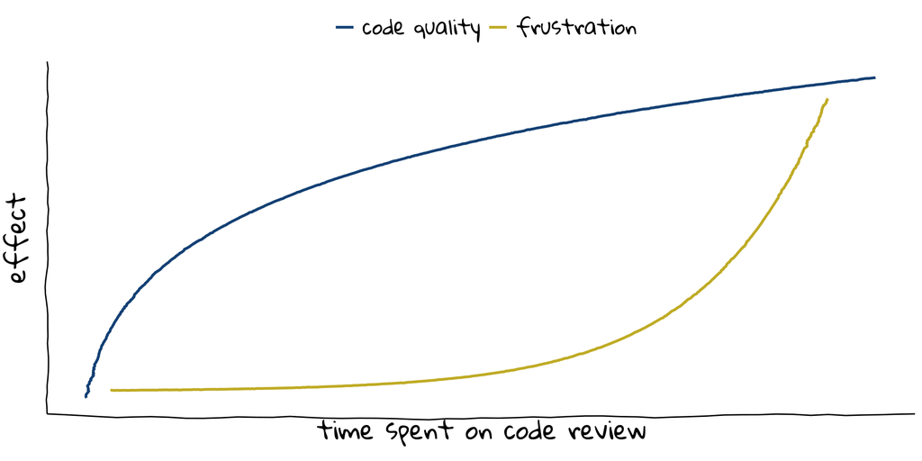

## Have you ever …

👩‍💻 submitted a pull request?  
🔍 performed a code review?  
🤔 thought about how to do code review better?

vote with 👍 and 👎 emojis

## Literal code review

📝 write some comments  
💻 run the code  
🔧 make direct suggestions  
👀 let’s review some code

## Why review code?

✔️ quality & compliance  
💡 provide ideas for improving the code  
🧠 knowledge transfer  
🚌 increase your bus number!

## What is a reviewer looking for?

🐛 potential bugs  
📈 quality of outputs  
🔢 check the mathematics and statistics  
💼 sensitive information!

## How should a reviewer behave?

❤️ be kind and **praise your team members**  
☕ take a break if you’re getting grumpy  
❓ ask open ended questions about the code  
🤖 automate the painful stuff: linters, stylers, CI/CD

## Code is never perfect

🩺 accept PRs when overall health is improved  
☎️ have a natter about the code  
🛠️ favour maintainable and readable code  
👪 broaden the discussion

## Triage your suggestions

🕷️ Nit: this is minor; I am being pedantic  
🤔 Consider: I’m not too bothered, would be nice  
🤷 FYI: out of scope, I think you’d like this approach  
⚠️ Should: an essential fix!

## Every team is unique

📰 come up with your own team code review style  
📣 agree on the style as a team activity  
♻️ trial it, review it, adapt it  
🖊️ document your process (use a [wiki](https://github.com/UKHSA-Internal/idm-pancasts/wiki/Code-review-for-Pancasters)!)

# Some thoughts on best practices

## best practices are always changing

🤔 come up with a sensible approach  
🖊️ document it, shout about it, adapt it  
🎯 apply the rules consistently  
🤷 anything else is just an opinion

## why adopt best practices?

⛵ we run a tight ship  
😩 decision fatigue  
💎 clarity leads to productivity  
🤷 maybe they should be called **standard practices**

## In review

🔑 code review is key to quality outputs  
👪 we all need to be reviewing code  
👏 be kind, supportive and encouraging  
⏩ keep code moving forward